# Scenarios: Design, Analysis, and Discussion

A Core-Periphery SOCIO-ECO-MRIO-SFC Model of Circular Economy Transitions

Author

Affiliation

Oriol Vallès Codina

Johns Hopkins University, Net Zero Industrial Policy Lab, Department of Political Science

Published

March 23, 2026

# 1 Overview

This section presents the full scenario analysis for the SOCIO-ECO-MRIO-SFC model of the EU–RoW economy. We study circular economy (CE) transitions through a two-pronged lens: **final demand reallocations** that shift household, government, and investment expenditures from primary to secondary material sectors; and **intermediate production substitutions** that alter input-output coefficients at the point of industrial production. Fourteen scenarios spanning food, energy, wood, pulp, plastics, metal, glass, cement, and construction sectors are evaluated.

The section is organized as follows. Section 2 characterizes the input-output structure of the EU–RoW economy and motivates the choice of scenarios. Section 3 formalizes scenario design and derives analytical predictions for material impact. Section 4 presents the simulated trajectories, contrasting baseline and shocked paths for macroeconomic, social, and ecological variables. Section 5 synthesizes findings around the **triple dilemma** — the structural tension between ecological improvement, macroeconomic stability, and social equity — with particular attention to EU–RoW asymmetries. Section 6 traces the material consumption trajectories and quantifies rebound effects. Section 7 offers a forward-looking discussion, including a disclaimer on the carbon-industry IO connections that our scenarios do not directly target.

# 2 The Input-Output Structure of the EU–RoW Economy

## 2.1 Sector Composition and Gross Output

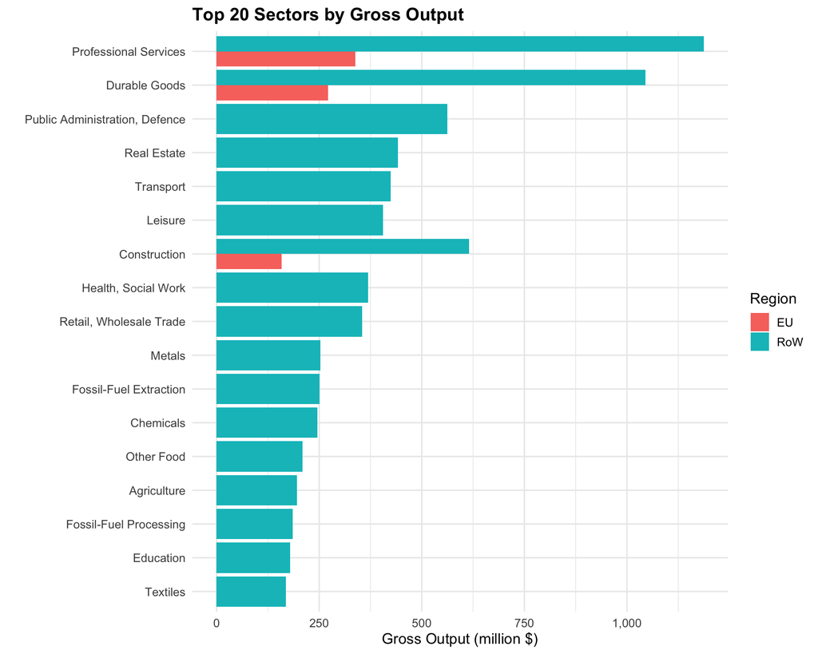

## 2.2 IO Network: Cross-Border Links

[figure not shown]

## 2.3 Ecological Intensities by Sector

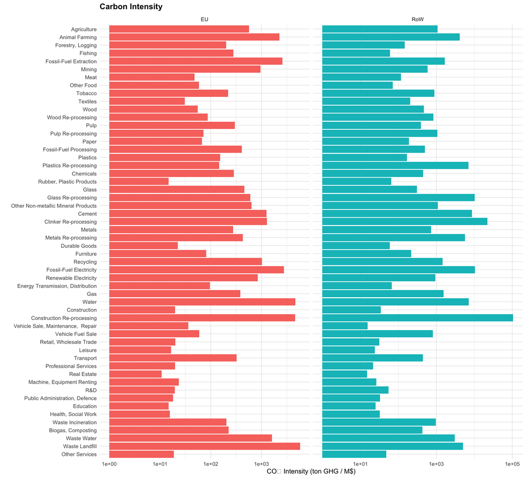

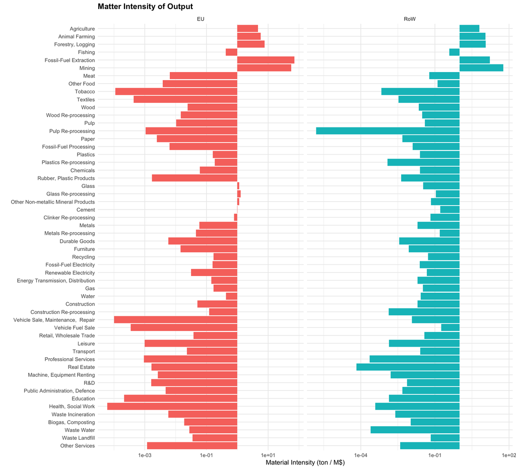

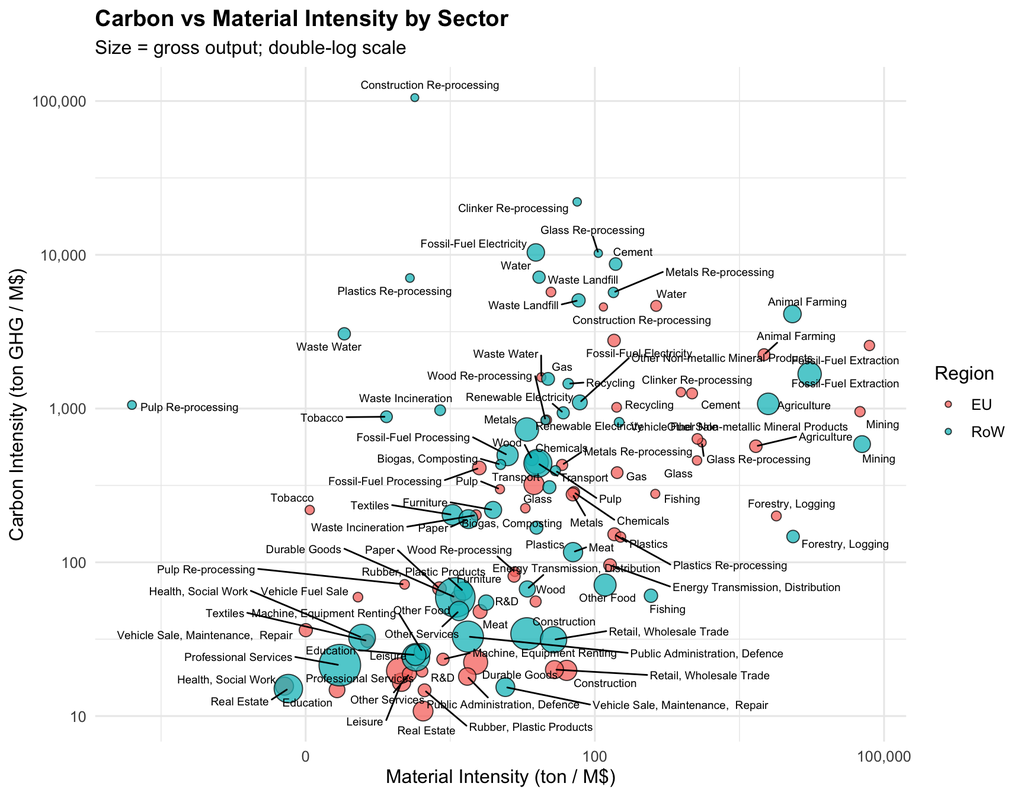

# 3 Scenario Design

## 3.1 Taxonomy and Registry

Table 1. Scenario Registry

[output not shown]

Scenarios 1–6 operate on the **final demand simplex**: household consumption shares ($\beta$), government consumption shares ($\sigma$), private investment shares ($\iota$), and public investment shares ($\iota^g$). Scenarios 7–14 operate on the **technical coefficient matrix** $A$, altering the industrial production recipe.

## 3.2 Formal Mechanics

### 3.2.1 Final Demand Reallocation

For demand component $D \in \{c, g, id, id^g\}$ with sector-level shares $\delta$, a parameter $\rho \in [0,1]$ governs the fractional reallocation from primary sector 1 to secondary sector 2:

$$\delta'_1 = (1-\rho)\,\delta_1, \qquad \delta'_2 = \delta_2 + \rho\,\delta_1.$$

This conserves the total budget ($\sum_j \delta'_j = 1$) while shifting composition. The induced material changes are:

$$\Delta M_1 = \rho\,\delta_1\,D\,(l_{12} - l_{11}), \qquad \Delta M_2 = \rho\,\delta_1\,D\,(l_{22} - l_{21}),$$

$$\boxed{\Delta M = \rho\,\delta_1\,D\,\bigl[(l_{12}+l_{22}) - (l_{11}+l_{21})\bigr].}$$

where $l_{ij}$ are entries of the Leontief inverse $L = (I - A)^{-1}$. A **structural rebound** occurs if $l_{12} > l_{11}$, i.e., the secondary sector generates more total primary-material requirements than the primary sector itself. This is possible when the secondary material is embedded in production chains with high primary material intensity.

### 3.2.2 Intermediate Production Substitution

For intermediate input substitution, the A-matrix is modified:

$$a'_{1j} = (1-\rho)\,a_{1j}, \qquad a'_{2j} = a_{2j} + \rho\,a_{1j}, \qquad a'_{ij} = a_{ij}\ (\text{otherwise}).$$

This preserves the material input bundle $s_j = a_{1j} + a_{2j}$, implies no change in total input requirements per unit output, and captures a recipe-preserving substitution. To first order in $\rho$:

$$\Delta x_i \approx \rho\,\sum_{j\in\mathcal{J}} a_{1j}\,x_j\,(l_{i2} - l_{i1}),$$

so that:

$$\boxed{\Delta M = \rho\,\biggl(\sum_{j\in\mathcal{J}} a_{1j}\,x_j\biggr)\,\bigl[(l_{12}+l_{22}) - (l_{11}+l_{21})\bigr].}$$

Formally, the final demand and intermediate demand formulas share the same structural factor $[(l_{12}+l_{22}) - (l_{11}+l_{21})]$. They differ only in the **scale factor**: $\delta_1 D$ for demand-side, $\sum_j a_{1j} x_j$ (total intermediate demand for the primary material) for supply-side.

## 3.3 Input-Output Structure: Incidence and Backward Linkages

[output not shown]

## 3.4 Analytical ΔM: Expected Material Impact by Scenario

This subsection derives and visualises the **first-order analytical prediction** for the change in primary material use $\Delta M_1$, secondary material use $\Delta M_2$, and total material use $\Delta M$, before running any simulation. These estimates depend on three ingredients:

1. The **structural factor** $\Lambda_{12} \equiv (l_{12}+l_{22}) - (l_{11}+l_{21})$: purely IO-structural, determines the direction and magnitude of the material-efficiency gain.
2. The **scale factor**: $\delta_1 D$ (final demand) or $\sum_j a_{1j} x_j$ (intermediate demand).
3. The substitution parameter $\rho = 0.2$.

Table 2. Analytical first-order material impacts by scenario (ρ = 0.2). ΔM1 EU = change in EU primary material sector output; ΔM1 RoW = change in RoW equivalent sector via MRIO multiplier; ΔM1 total = EU + RoW combined.

| # | Scenario | Domain | From | To | Lambda (structural) | Scale factor | ΔM1 EU (primary) | ΔM1 RoW | ΔM1 total | ΔM2 (secondary) | ΔM (total) |
| --- | --- | --- | --- | --- | --- | --- | --- | --- | --- | --- | --- |
| 1 | Scenario 1 \| Final Demand \| Household Consumption \| Food Shift | Final Demand | Meat | Other Food | -0.0377 | 24.5333 | -5.0611 | 0.0136 | -5.0475 | 4.8762 | -0.1849 |
| 2 | Scenario 2 \| Final Demand \| Household Consumption \| Energy Shift | Final Demand | Fossil-Fuel Electricity | Renewable Electricity | -0.0041 | 6.8851 | -1.3815 | -0.0030 | -1.3846 | 1.3759 | -0.0056 |
| 3 | Scenario 3 \| Final Demand \| Government Consumption \| Cement Shift | Final Demand | Cement | Clinker Re-processing | 0.0212 | 0.0282 | -0.0056 | 0.0000 | -0.0056 | 0.0057 | 0.0001 |
| 4 | Scenario 4 \| Final Demand \| Government Consumption \| Plastics Shift | Final Demand | Plastics | Plastics Re-processing | -0.0056 | 12.3187 | -2.4791 | 0.0050 | -2.4741 | 2.4654 | -0.0137 |
| 5 | Scenario 5 \| Final Demand \| Firm Investment \| Cement Shift | Final Demand | Cement | Clinker Re-processing | 0.0212 | 0.1981 | -0.0395 | 0.0000 | -0.0395 | 0.0404 | 0.0008 |
| 6 | Scenario 6 \| Final Demand \| Firm Investment \| Plastics Shift | Final Demand | Plastics | Plastics Re-processing | -0.0056 | 0.6257 | -0.1259 | 0.0003 | -0.1257 | 0.1252 | -0.0007 |
| 7 | Scenario 7 \| Intermediate Demand \| Firm Production \| Wood Shift | Intermediate Demand | Wood | Wood Re-processing | 0.0229 | 28.6159 | -5.7556 | 0.0373 | -5.7183 | 5.8869 | 0.1313 |
| 8 | Scenario 8 \| Intermediate Demand \| Firm Production \| Pulp Shift | Intermediate Demand | Pulp | Pulp Re-processing | 0.0000 | 5.4133 | -1.0829 | 0.0001 | -1.0828 | 1.0829 | 0.0000 |
| 9 | Scenario 9 \| Intermediate Demand \| Firm Production \| Plastics Shift | Intermediate Demand | Plastics | Plastics Re-processing | -0.0056 | 44.9913 | -9.0545 | 0.0183 | -9.0361 | 9.0044 | -0.0501 |
| 10 | Scenario 10 \| Intermediate Demand \| Firm Production \| Metal Shift | Intermediate Demand | Metals | Metals Re-processing | -0.0264 | 109.3432 | -23.1287 | -0.2281 | -23.3568 | 22.5506 | -0.5781 |
| 11 | Scenario 11 \| Intermediate Demand \| Firm Production \| Glass Shift | Intermediate Demand | Glass | Glass Re-processing | -0.1619 | 10.7009 | -2.4025 | -0.0479 | -2.4505 | 2.0561 | -0.3464 |
| 12 | Scenario 12 \| Intermediate Demand \| Firm Production \| Cement Shift | Intermediate Demand | Cement | Clinker Re-processing | 0.0212 | 32.4465 | -6.4783 | 0.0007 | -6.4777 | 6.6162 | 0.1378 |
| 13 | Scenario 13 \| Intermediate Demand \| Firm Production \| Energy Shift | Intermediate Demand | Fossil-Fuel Electricity | Renewable Electricity | -0.0041 | 63.3130 | -12.7039 | -0.0279 | -12.7318 | 12.6520 | -0.0519 |
| 14 | Scenario 14 \| Intermediate Demand \| Firm Production \| Construction Shift | Intermediate Demand | Construction | Construction Re-processing | -0.1844 | 160.6332 | -38.0436 | -0.1190 | -38.1625 | 32.1202 | -5.9234 |

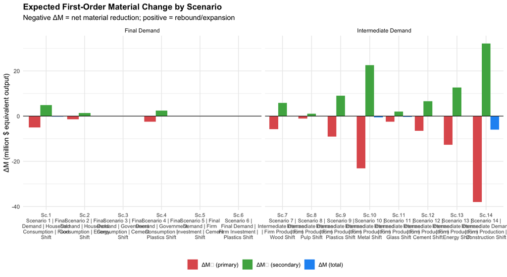

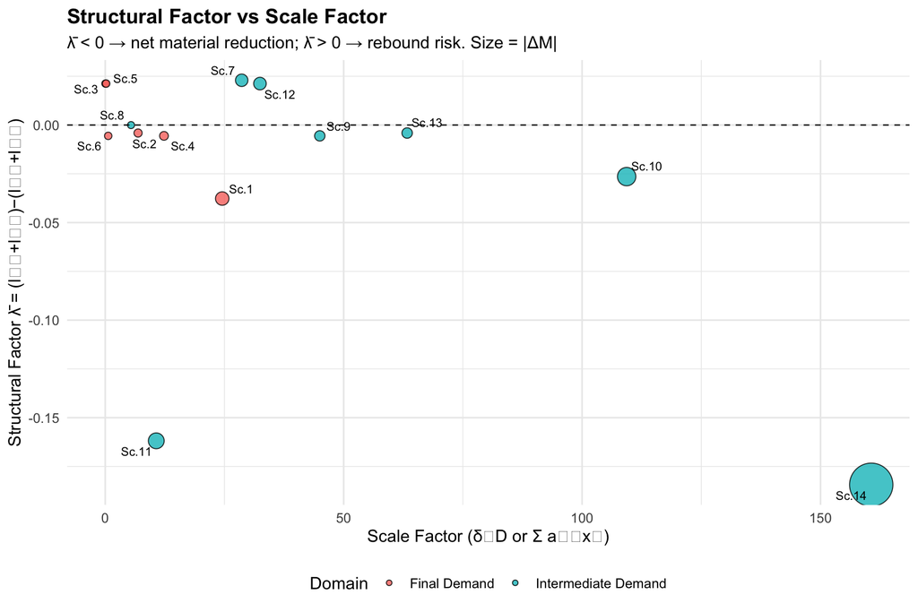

> **Interpretation.** The structural factor $\bar{\lambda}$ determines whether a substitution reduces or increases total material throughput. A negative $\bar{\lambda}$ means the secondary sector has a lower combined material requirement than the primary sector — the green transition genuinely reduces material use. A positive $\bar{\lambda}$ indicates a structural rebound: secondary production is more material-intensive than primary, so substitution paradoxically increases total material throughput. The scale factor ($\delta_1 D$ or $\Sigma_j a_{1j} x_j$) amplifies or attenuates the structural signal depending on how large the affected demand component is relative to total output.

### 3.4.1 Why Final Demand Scale Factors Are Small: The Household Budget Landscape

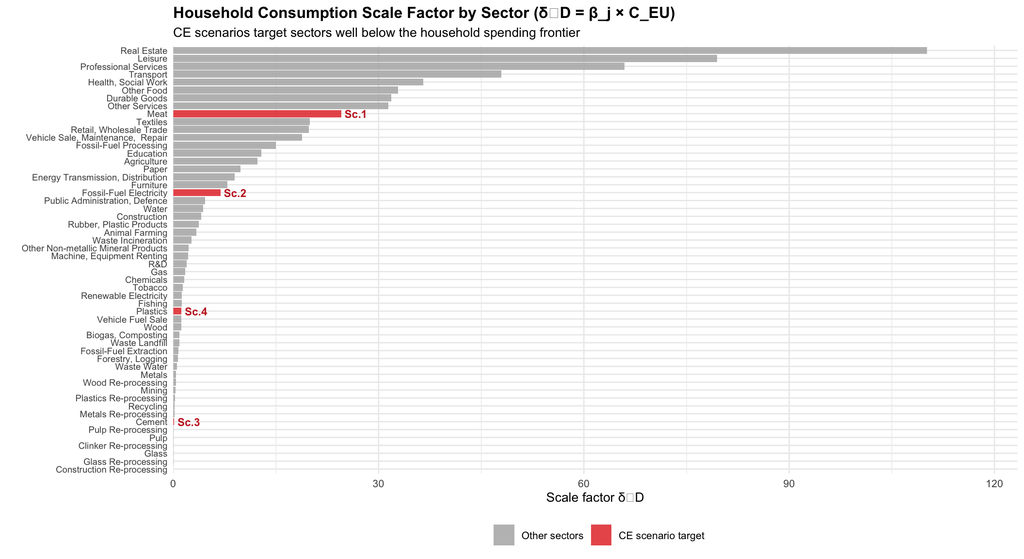

> The household spending frontier is dominated by service sectors (Real Estate: 110, Leisure: 79, Professional Services: 66, Transport: 48) that carry low material intensity and are not typical CE targets. Among primary-material sectors, Other Food (33) and Meat (25) have the largest shares. Fossil-fuel electricity (Sc.2, scale = 6.9) ranks low because it represents a small share of final household expenditure — most energy costs are embedded in intermediate production chains, not direct consumer spending.

### 3.4.2 Intermediate Demand: Scale Dominates, Fossil Fuel Connections

For intermediate production substitution scenarios (Sc.7–14), both the scale factor and the structural factor matter. The chart below decomposes the scale factor $\sum_j a_{1j} x_j$ for each intermediate scenario into its **top contributing user sectors** — i.e., which industries account for most of the primary material’s intermediate use. For the fossil-fuel electricity scenario (Sc.13), this reveals which sectors would be most affected by a switch from fossil to renewable electricity in production.

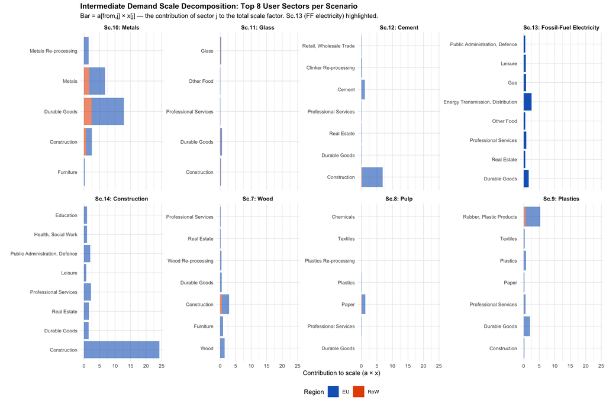

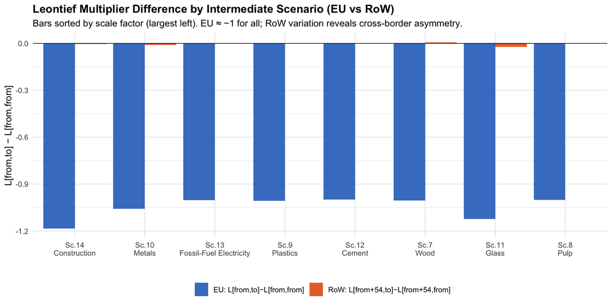

# 4 Simulation Results

## 4.1 Sample Scenario Trajectories

We present simulation trajectories for three representative scenarios from the three regimes identified in the analysis: a final demand shock (Scenario 1), an intermediate production restructuring (Scenario 13: Energy), and the construction expansion (Scenario 14). These illustrate the qualitatively distinct adjustment dynamics at work.

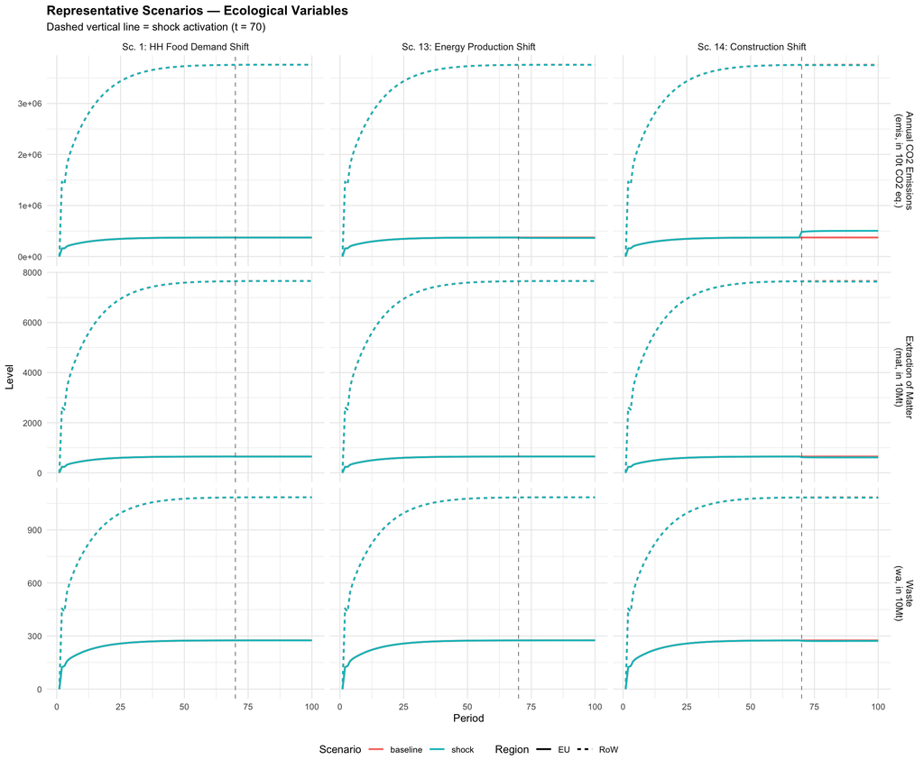

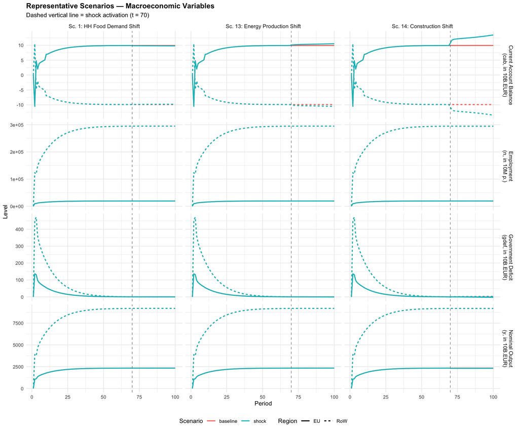

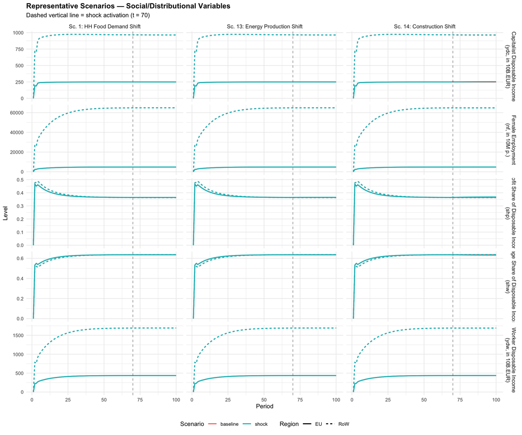

## 4.2 Cross-Scenario Heatmap

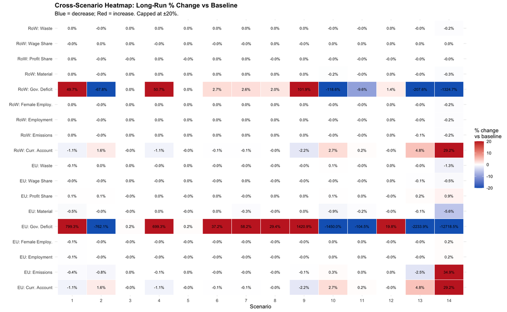

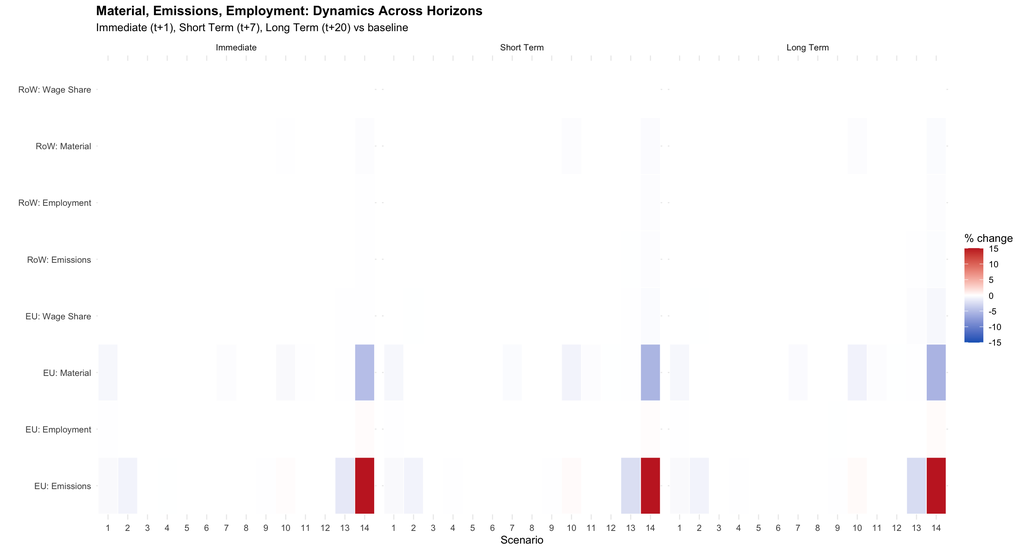

# 5 The Triple Dilemma: Ecological, Economic, and Social Outcomes

The scenario space does not yield a single “win-win” path. Instead, three structurally distinct transition regimes emerge, each positioning itself differently on the **trilemma between ecological improvement, macroeconomic stability, and social equity**. Table 3 provides a compact comparative matrix.

Table 3. Compact Regime Matrix (Long Run)

[output not shown]

**Legend:** ++ strongly positive, + positive, 0 negligible, − negative, −− strongly negative, ± mixed/sign-changes across horizons.

## 5.1 Regime A: Construction Expansion

The mechanism is straightforward: construction is a high-output-multiplier sector with strong backward linkages into the domestic economy. The substitution increases demand for secondary construction materials — which are produced locally — generating a Keynesian multiplier effect that dominates the restructuring cost.

## 5.2 Regime B: Final Demand Reallocation

Scenarios 1–6 implement household, government, and investment expenditure shifts away from primary food, energy, and material sectors. The leverage of these interventions is structurally limited. Because the affected demand shares ($\delta_1 D$) are small relative to total economic activity, the scale factor is modest regardless of $\bar{\lambda}$.

The simulation confirms this: output falls marginally or remains near-neutral, employment changes are small, and distributional effects are negligible. The ecological improvement — while genuine — is proportionally modest: a 20% shift in one demand share produces a corresponding fraction of the economy’s material and emissions footprint.

This regime illustrates the **incremental vs structural** dimension of the trilemma. Consumer-side and expenditure-side policies are coherent with social stability and entail minimal macro risk, but they cannot deliver the material throughput reductions required for a substantive ecological transition. They function best as complements to supply-side restructuring, not substitutes.

RoW spillovers are minimal, consistent with the limited systemic reach of final demand shocks.

## 5.3 Regime C: Intermediate Production Restructuring

Scenarios 7–13 operate at the production core of the economy, altering the technical coefficients of wood, pulp, plastics, metal, glass, cement, and energy sectors. This is where the trilemma is most acute.

**Macroeconomic contraction** accompanies these gains, however. Output declines across all horizons as the technology shift reduces gross output multipliers. Investment falls as firms adjust to the new input regime. The government fiscal position deteriorates as reduced activity compresses tax revenues while public expenditure adjusts more slowly. The scale of contraction is approximately proportional to the breadth of the affected sector: energy (widespread incidence) produces the largest macro effect.

**Distributional shift toward capital** is the most concerning social dynamic. As employment falls and productivity gains accrue to capital owners — who capture the reduced input costs without fully passing them on to wages — the wage share declines and the profit share rises. Worker disposable income contracts, and the effect strengthens over time: the distributional deterioration is a medium-run structural shift, not a transient adjustment cost. Female employment falls disproportionately in several scenarios, reflecting sectoral feminization patterns in the affected upstream industries.

## 5.4 Core–Periphery Structural Asymmetry

These asymmetries do not disappear with policy design: they are structural features of the current IO topology. Addressing them requires either direct policy coordination across regions or explicit compensation mechanisms — a governance challenge beyond the scope of the scenarios modelled here, but central to the JUST2CE framework.

# 6 Material Consumption Trajectories and Rebound Effects

## 6.1 Primary Material Consumption: Baseline vs Shock

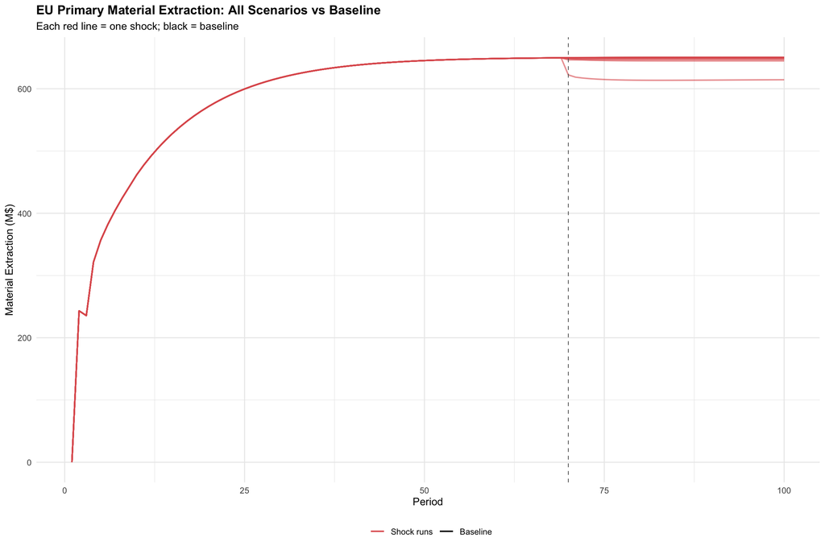

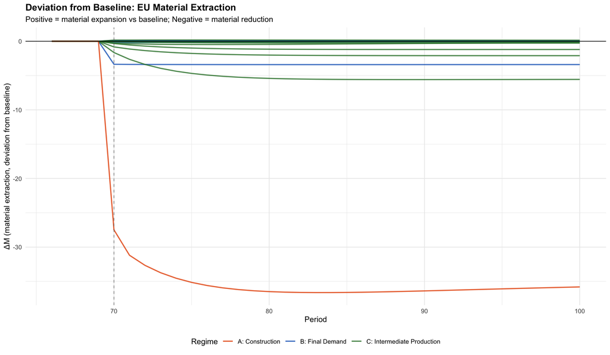

## 6.2 Cumulative Material Stock Differences

The trajectory of the instantaneous deviation ($\Delta M_t$) does not fully capture the aggregate material throughput effect of a policy, because a brief but large reduction can be offset by a subsequent rebound. To assess the net cumulative effect, we compute:

$$\Delta M^{\text{cum}}_t = \sum_{\tau = t_{\text{shock}}}^{t} \Delta M_\tau = \sum_{\tau = t_{\text{shock}}}^{t} (M_\tau^{\text{shock}} - M_\tau^{\text{baseline}}).$$

A monotonically declining $\Delta M^{\text{cum}}_t$ indicates a genuine, sustained material reduction. A curve that flattens or reverses indicates a rebound where the initial reduction is partially or fully undone by subsequent increases.

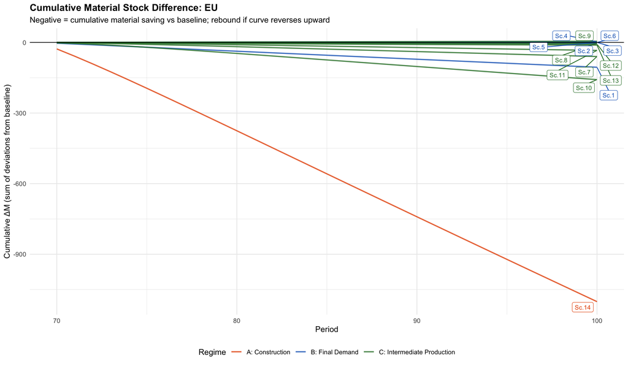

## 6.3 Sectoral Material Output Trajectories

The aggregate material indicator $M$ conceals important heterogeneity across material categories. Each CE scenario targets a specific primary-to-secondary substitution, so its first-order effect should be visible in the output of the targeted sector. The plots below show the **% deviation from baseline** in gross output for the primary material sectors studied in the scenario table: food, fossil-fuel electricity, wood, pulp, plastics, metals, glass, cement, and construction. This is the sector-level analogue of the aggregate material and emissions trajectories: rather than tracking total material extraction, we track the output of the industries that extract or process specific material types.

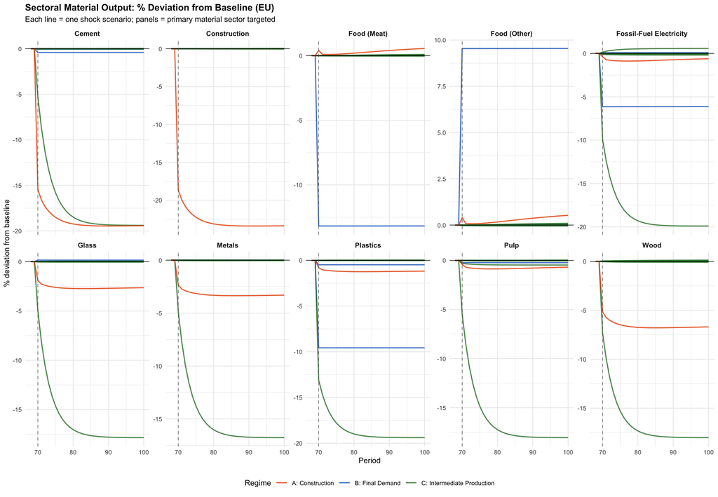

> **Reading the sectoral plots.** Each panel shows the trajectory of EU gross output in one primary material sector across all 14 scenarios. The directly targeted scenario (e.g., Wood shift → Scenario 7) should show the largest deviation in the Wood panel. Scenarios affecting the same sector indirectly — through intermediate linkages — produce smaller cross-panel spillovers. Final-demand scenarios (blue) generally produce smaller deviations than intermediate-production scenarios (green) because they operate through a narrower demand channel. The Construction scenario (orange) appears across multiple panels due to its large backward linkages with cement, metals, and glass.

# 7 Discussion and Forward Look

## 7.1 The Triple Dilemma in Context

This trilemma is not an artefact of model parameterisation. It reflects deep structural features of the EU–RoW IO topology: the primary material sectors targeted for reduction are precisely those with the strongest backward linkages and highest employment multipliers. Substituting toward secondary materials reduces the output and employment generated per unit of final demand, even as it improves the material and emissions profile.

Policy implications are direct: a “just transition” cannot be achieved through CE restructuring alone. Complementary instruments — wage protection, green employment programmes, progressive fiscal policy, active labour market support — are structural prerequisites if the transition is not to be simultaneously ecologically successful and socially regressive. The Core–Periphery dimension adds a coordination imperative: without explicit EU–RoW policy coordination, the ecological gains of the EU transition may be partially purchased at the cost of output and employment losses in RoW — a transfer from Periphery to Core that contradicts the normative objectives of JUST2CE.

## 7.2 Scenario Leverage: Which Scenarios Matter Most?

The analytical ΔM estimates allow us to rank scenarios by their structural leverage before simulation:

- **Structural factor** $\bar{\lambda}$: determines the direction and per-unit magnitude of material change.
- **Scale factor**: determines the size of the affected demand or intermediate input stream.
- **Combined ΔM** = $\rho \times \text{scale} \times \bar{\lambda}$: the first-order expected material impact.

The practical implication is that **scenario prioritisation can be done analytically** using the ΔM table before running any simulations, saving computational resources and directing policy attention toward high-leverage interventions.

## 7.3 Asymmetric Rebound: Why Secondary ≠ Circular

A recurring structural insight from the Leontief analysis is that the circular economy benefit of substitution is not guaranteed. The sign and magnitude of $\Delta M$ depend on whether the secondary sector has lower embedded material requirements ($l_{12} + l_{22}$) than the primary sector ($l_{11} + l_{21}$). This comparison is non-trivial: secondary material production often requires energy-intensive processing (smelting, recycling, remanufacturing), so its total requirements may exceed those of the primary material for some sector pairs.

Where $\bar{\lambda} > 0$ (rebound regime), a policy framed as “circular economy” actually increases total material throughput. The model can thus identify when circularity is nominal (input substitution without material efficiency gain) versus genuine (structural reduction in material intensity). This distinction is policy-critical: only scenarios with $\bar{\lambda} < 0$ deliver authentic material footprint reductions.

## 7.4 Forward Look: The Carbon-Industry IO Connection

The scenario suite presented here focuses on a broad set of CE substitutions, treating the EU–RoW economy as a general input-output system. It does not directly model the sector where the EU–RoW IO connection is most concentrated: the fossil-fuel chain (RoW fossil-fuel extraction → EU fossil-fuel processing). This chain is, by a substantial margin, the dominant cross-border production link in the technical coefficient matrix.

This omission is deliberate at this stage of the research: our objective was to characterise the general CE substitution space, not to model a specific geopolitical scenario. Nevertheless, the omission generates a relevant limitation. The scenarios where EU restructuring most directly affects the dominant cross-border link — specifically, the energy sector scenarios (Sc.13) — do so indirectly via reduced energy demand, not by explicitly modelling a fossil-fuel supply disruption.

**Future research directions:** A natural extension of this work is to design a targeted scenario set that explicitly models the fossil-fuel chain disruption — a shock to the RoW fossil-fuel extraction → EU fossil-fuel processing coefficient — under different policy responses. This would allow the model to directly quantify the macroeconomic, social, and ecological consequences of:

1. **Energy sanctions** or supply disruptions (e.g., the US–Iran confrontation) that reduce RoW fossil-fuel exports to EU;
2. **Accelerated EU energy transition** driven by geopolitical necessity rather than climate policy;
3. **RoW fossil-fuel substitution** — the equivalent of our CE scenarios applied specifically to the dominant cross-border link.

Such an extension would require calibrating the shock magnitudes from trade data (e.g., BACI, Comext, IEA) and mapping them to the IO framework. The workplan foresees this as Phase 1 of the second year of the project (April–June 2026). The results presented here provide the baseline characterisation against which such targeted scenarios should be benchmarked.

# 8 Appendix: Scenario Details and Summary Statistics

## 8.1 Full Summary Tables by Scenario

### 8.1.1 Scenario 1 : Scenario 1 | Final Demand | Household Consumption | Food Shift

Scenario 1 — % change vs baseline

| Name | Variable | Immediate.Z1 | Short.Term.Z1 | Long.Term.Z1 | Immediate.Z2 | Short.Term.Z2 | Long.Term.Z2 |
| --- | --- | --- | --- | --- | --- | --- | --- |
| Macroeconomic | c | -0.02 | -0.02 | -0.02 | 0.00 | 0.00 | 0.01 |
| Macroeconomic | va | -0.02 | -0.02 | -0.02 | 0.00 | 0.00 | 0.01 |
| Macroeconomic | go | -0.04 | -0.04 | -0.04 | 0.00 | 0.00 | 0.01 |
| Macroeconomic | id | -0.02 | -0.04 | -0.04 | 0.00 | 0.00 | 0.01 |
| Macroeconomic | gdef | 36.91 | 74.05 | 799.29 | -25.28 | 85.77 | 49.72 |
| Macroeconomic | cab | -0.68 | -0.82 | -1.12 | -0.68 | -0.82 | -1.12 |
| Macroeconomic | tb | -0.30 | -0.28 | -0.28 | -0.30 | -0.28 | -0.28 |
| Social | n | -0.09 | -0.09 | -0.09 | 0.01 | 0.01 | 0.01 |
| Social | nf | -0.09 | -0.09 | -0.09 | 0.01 | 0.01 | 0.01 |
| Social | shp | 0.04 | 0.04 | 0.05 | 0.00 | 0.00 | 0.00 |
| Social | shw | -0.02 | -0.02 | -0.03 | 0.00 | 0.00 | 0.00 |
| Debt.and.Wealth | lh | 0.00 | 0.00 | -0.01 | 0.00 | 0.00 | 0.00 |
| Debt.and.Wealth | lf | -0.03 | -0.14 | -0.22 | 0.00 | 0.00 | 0.00 |
| Debt.and.Wealth | v | 0.00 | 0.00 | 0.00 | 0.00 | 0.00 | 0.01 |
| Debt.and.Wealth | k | -0.01 | -0.03 | -0.04 | 0.00 | 0.00 | 0.01 |
| Debt.and.Wealth | b_s | 0.01 | 0.05 | 0.16 | 0.00 | -0.01 | -0.03 |
| Ecological | x_mat | -0.30 | -0.31 | -0.31 | 0.01 | 0.01 | 0.01 |
| Ecological | land | -0.43 | -0.43 | -0.43 | 0.01 | 0.01 | 0.01 |
| Ecological | mat | -0.52 | -0.52 | -0.52 | 0.01 | 0.01 | 0.01 |
| Ecological | rec | 0.01 | 0.00 | 0.00 | 0.00 | 0.00 | 0.01 |
| Ecological | emis | -0.43 | -0.43 | -0.43 | 0.01 | 0.01 | 0.01 |
| Ecological | wa | -0.04 | -0.05 | -0.05 | 0.00 | 0.00 | 0.01 |
| Ecological | water | -0.43 | -0.43 | -0.43 | 0.01 | 0.01 | 0.01 |

### 8.1.2 Scenario 2 : Scenario 2 | Final Demand | Household Consumption | Energy Shift

Scenario 2 — % change vs baseline

| Name | Variable | Immediate.Z1 | Short.Term.Z1 | Long.Term.Z1 | Immediate.Z2 | Short.Term.Z2 | Long.Term.Z2 |
| --- | --- | --- | --- | --- | --- | --- | --- |
| Macroeconomic | c | 0.00 | 0.01 | 0.03 | 0.00 | -0.01 | -0.01 |
| Macroeconomic | va | 0.01 | 0.02 | 0.03 | -0.01 | -0.01 | -0.01 |
| Macroeconomic | go | -0.01 | -0.01 | 0.00 | -0.01 | -0.01 | -0.01 |
| Macroeconomic | id | -0.01 | -0.01 | 0.00 | 0.00 | -0.01 | -0.01 |
| Macroeconomic | gdef | -1.80 | -30.53 | -762.12 | 37.82 | -124.61 | -67.78 |
| Macroeconomic | cab | 1.11 | 1.22 | 1.55 | 1.11 | 1.22 | 1.55 |
| Macroeconomic | tb | 0.66 | 0.61 | 0.53 | 0.66 | 0.61 | 0.53 |
| Social | n | -0.01 | -0.01 | 0.00 | 0.00 | -0.01 | -0.01 |
| Social | nf | -0.01 | -0.01 | 0.00 | 0.00 | -0.01 | -0.01 |
| Social | shp | 0.06 | 0.07 | 0.07 | 0.00 | 0.00 | 0.00 |
| Social | shw | -0.03 | -0.04 | -0.04 | 0.00 | 0.00 | 0.00 |
| Debt.and.Wealth | lh | 0.00 | 0.00 | 0.00 | 0.00 | 0.00 | 0.00 |
| Debt.and.Wealth | lf | -0.04 | -0.13 | -0.21 | 0.00 | 0.00 | -0.01 |
| Debt.and.Wealth | v | 0.01 | 0.03 | 0.06 | 0.00 | 0.00 | -0.01 |
| Debt.and.Wealth | k | 0.00 | -0.01 | 0.00 | 0.00 | 0.00 | -0.01 |
| Debt.and.Wealth | b_s | 0.00 | -0.01 | -0.09 | 0.00 | 0.01 | 0.04 |
| Ecological | x_mat | -0.64 | -0.64 | -0.63 | -0.02 | -0.03 | -0.03 |
| Ecological | land | -0.80 | -0.79 | -0.78 | -0.01 | -0.01 | -0.01 |
| Ecological | mat | -0.03 | -0.02 | -0.01 | 0.00 | -0.01 | -0.01 |
| Ecological | rec | -1.52 | -1.52 | -1.51 | -0.06 | -0.06 | -0.06 |
| Ecological | emis | -0.80 | -0.79 | -0.78 | -0.01 | -0.01 | -0.01 |
| Ecological | wa | -0.01 | -0.01 | 0.00 | -0.01 | -0.01 | -0.01 |
| Ecological | water | -0.80 | -0.79 | -0.78 | -0.01 | -0.01 | -0.01 |

### 8.1.3 Scenario 3 : Scenario 3 | Final Demand | Government Consumption | Cement Shift

Scenario 3 — % change vs baseline

| Name | Variable | Immediate.Z1 | Short.Term.Z1 | Long.Term.Z1 | Immediate.Z2 | Short.Term.Z2 | Long.Term.Z2 |
| --- | --- | --- | --- | --- | --- | --- | --- |
| Macroeconomic | c | 0.00 | 0.00 | 0.00 | 0.00 | 0.00 | 0.00 |
| Macroeconomic | va | 0.00 | 0.00 | 0.00 | 0.00 | 0.00 | 0.00 |
| Macroeconomic | go | 0.00 | 0.00 | 0.00 | 0.00 | 0.00 | 0.00 |
| Macroeconomic | id | 0.00 | 0.00 | 0.00 | 0.00 | 0.00 | 0.00 |
| Macroeconomic | gdef | 0.01 | 0.01 | 0.16 | -0.01 | 0.03 | 0.01 |
| Macroeconomic | cab | 0.00 | 0.00 | 0.00 | 0.00 | 0.00 | 0.00 |
| Macroeconomic | tb | 0.00 | 0.00 | 0.00 | 0.00 | 0.00 | 0.00 |
| Social | n | 0.00 | 0.00 | 0.00 | 0.00 | 0.00 | 0.00 |
| Social | nf | 0.00 | 0.00 | 0.00 | 0.00 | 0.00 | 0.00 |
| Social | shp | 0.00 | 0.00 | 0.00 | 0.00 | 0.00 | 0.00 |
| Social | shw | 0.00 | 0.00 | 0.00 | 0.00 | 0.00 | 0.00 |
| Debt.and.Wealth | lh | 0.00 | 0.00 | 0.00 | 0.00 | 0.00 | 0.00 |
| Debt.and.Wealth | lf | 0.00 | 0.00 | 0.00 | 0.00 | 0.00 | 0.00 |
| Debt.and.Wealth | v | 0.00 | 0.00 | 0.00 | 0.00 | 0.00 | 0.00 |
| Debt.and.Wealth | k | 0.00 | 0.00 | 0.00 | 0.00 | 0.00 | 0.00 |
| Debt.and.Wealth | b_s | 0.00 | 0.00 | 0.00 | 0.00 | 0.00 | 0.00 |
| Ecological | x_mat | 0.00 | 0.00 | 0.00 | 0.00 | 0.00 | 0.00 |
| Ecological | land | 0.00 | 0.00 | 0.00 | 0.00 | 0.00 | 0.00 |
| Ecological | mat | 0.00 | 0.00 | 0.00 | 0.00 | 0.00 | 0.00 |
| Ecological | rec | 0.00 | 0.00 | 0.00 | 0.00 | 0.00 | 0.00 |
| Ecological | emis | 0.00 | 0.00 | 0.00 | 0.00 | 0.00 | 0.00 |
| Ecological | wa | 0.00 | 0.00 | 0.00 | 0.00 | 0.00 | 0.00 |
| Ecological | water | 0.00 | 0.00 | 0.00 | 0.00 | 0.00 | 0.00 |

### 8.1.4 Scenario 4 : Scenario 4 | Final Demand | Government Consumption | Plastics Shift

Scenario 4 — % change vs baseline

| Name | Variable | Immediate.Z1 | Short.Term.Z1 | Long.Term.Z1 | Immediate.Z2 | Short.Term.Z2 | Long.Term.Z2 |
| --- | --- | --- | --- | --- | --- | --- | --- |
| Macroeconomic | c | -0.02 | -0.02 | -0.02 | 0.00 | 0.00 | 0.01 |
| Macroeconomic | va | -0.02 | -0.02 | -0.02 | 0.00 | 0.01 | 0.01 |
| Macroeconomic | go | -0.02 | -0.02 | -0.02 | 0.01 | 0.01 | 0.01 |
| Macroeconomic | id | -0.01 | -0.02 | -0.02 | 0.00 | 0.00 | 0.01 |
| Macroeconomic | gdef | 23.20 | 54.06 | 699.31 | -29.47 | 94.31 | 50.68 |
| Macroeconomic | cab | -0.73 | -0.84 | -1.11 | -0.73 | -0.84 | -1.11 |
| Macroeconomic | tb | -0.35 | -0.32 | -0.30 | -0.35 | -0.32 | -0.30 |
| Social | n | -0.02 | -0.02 | -0.02 | 0.00 | 0.01 | 0.01 |
| Social | nf | -0.02 | -0.02 | -0.02 | 0.00 | 0.01 | 0.01 |
| Social | shp | 0.01 | 0.02 | 0.02 | 0.00 | 0.00 | 0.00 |
| Social | shw | -0.01 | -0.01 | -0.01 | 0.00 | 0.00 | 0.00 |
| Debt.and.Wealth | lh | 0.00 | 0.00 | -0.01 | 0.00 | 0.00 | 0.00 |
| Debt.and.Wealth | lf | 0.00 | -0.04 | -0.06 | 0.00 | 0.01 | 0.01 |
| Debt.and.Wealth | v | 0.00 | -0.01 | -0.01 | 0.00 | 0.00 | 0.01 |
| Debt.and.Wealth | k | 0.00 | -0.01 | -0.02 | 0.00 | 0.00 | 0.01 |
| Debt.and.Wealth | b_s | 0.01 | 0.04 | 0.12 | 0.00 | -0.01 | -0.03 |
| Ecological | x_mat | -0.04 | -0.04 | -0.05 | 0.00 | 0.00 | 0.01 |
| Ecological | land | -0.04 | -0.05 | -0.05 | 0.01 | 0.01 | 0.01 |
| Ecological | mat | 0.02 | 0.01 | 0.01 | 0.01 | 0.01 | 0.01 |
| Ecological | rec | -0.12 | -0.12 | -0.13 | -0.01 | -0.01 | -0.01 |
| Ecological | emis | -0.04 | -0.05 | -0.05 | 0.01 | 0.01 | 0.01 |
| Ecological | wa | -0.02 | -0.02 | -0.02 | 0.01 | 0.01 | 0.01 |
| Ecological | water | -0.04 | -0.05 | -0.05 | 0.01 | 0.01 | 0.01 |

### 8.1.5 Scenario 5 : Scenario 5 | Final Demand | Firm Investment | Cement Shift

Scenario 5 — % change vs baseline

| Name | Variable | Immediate.Z1 | Short.Term.Z1 | Long.Term.Z1 | Immediate.Z2 | Short.Term.Z2 | Long.Term.Z2 |
| --- | --- | --- | --- | --- | --- | --- | --- |
| Macroeconomic | c | 0.00 | 0.00 | 0.00 | 0.00 | 0.00 | 0.00 |
| Macroeconomic | va | 0.00 | 0.00 | 0.00 | 0.00 | 0.00 | 0.00 |
| Macroeconomic | go | 0.00 | 0.00 | 0.00 | 0.00 | 0.00 | 0.00 |
| Macroeconomic | id | 0.00 | 0.00 | 0.00 | 0.00 | 0.00 | 0.00 |
| Macroeconomic | gdef | -0.03 | -0.02 | 0.23 | -0.05 | 0.08 | 0.03 |
| Macroeconomic | cab | 0.00 | 0.00 | 0.00 | 0.00 | 0.00 | 0.00 |
| Macroeconomic | tb | 0.00 | 0.00 | 0.00 | 0.00 | 0.00 | 0.00 |
| Social | n | 0.00 | 0.00 | 0.00 | 0.00 | 0.00 | 0.00 |
| Social | nf | 0.00 | 0.00 | 0.00 | 0.00 | 0.00 | 0.00 |
| Social | shp | 0.00 | 0.00 | 0.00 | 0.00 | 0.00 | 0.00 |
| Social | shw | 0.00 | 0.00 | 0.00 | 0.00 | 0.00 | 0.00 |
| Debt.and.Wealth | lh | 0.00 | 0.00 | 0.00 | 0.00 | 0.00 | 0.00 |
| Debt.and.Wealth | lf | 0.00 | 0.00 | 0.00 | 0.00 | 0.00 | 0.00 |
| Debt.and.Wealth | v | 0.00 | 0.00 | 0.00 | 0.00 | 0.00 | 0.00 |
| Debt.and.Wealth | k | 0.00 | 0.00 | 0.00 | 0.00 | 0.00 | 0.00 |
| Debt.and.Wealth | b_s | 0.00 | 0.00 | 0.00 | 0.00 | 0.00 | 0.00 |
| Ecological | x_mat | 0.00 | 0.00 | 0.00 | 0.00 | 0.00 | 0.00 |
| Ecological | land | 0.00 | 0.00 | 0.00 | 0.00 | 0.00 | 0.00 |
| Ecological | mat | 0.00 | 0.00 | 0.00 | 0.00 | 0.00 | 0.00 |
| Ecological | rec | 0.00 | 0.00 | 0.00 | 0.00 | 0.00 | 0.00 |
| Ecological | emis | 0.00 | 0.00 | 0.00 | 0.00 | 0.00 | 0.00 |
| Ecological | wa | 0.00 | 0.00 | 0.00 | 0.00 | 0.00 | 0.00 |
| Ecological | water | 0.00 | 0.00 | 0.00 | 0.00 | 0.00 | 0.00 |

### 8.1.6 Scenario 6 : Scenario 6 | Final Demand | Firm Investment | Plastics Shift

Scenario 6 — % change vs baseline

| Name | Variable | Immediate.Z1 | Short.Term.Z1 | Long.Term.Z1 | Immediate.Z2 | Short.Term.Z2 | Long.Term.Z2 |
| --- | --- | --- | --- | --- | --- | --- | --- |
| Macroeconomic | c | 0.00 | 0.00 | 0.00 | 0.00 | 0.00 | 0.00 |
| Macroeconomic | va | 0.00 | 0.00 | 0.00 | 0.00 | 0.00 | 0.00 |
| Macroeconomic | go | 0.00 | 0.00 | 0.00 | 0.00 | 0.00 | 0.00 |
| Macroeconomic | id | 0.00 | 0.00 | 0.00 | 0.00 | 0.00 | 0.00 |
| Macroeconomic | gdef | 1.31 | 2.94 | 37.23 | -1.51 | 4.99 | 2.69 |
| Macroeconomic | cab | -0.04 | -0.04 | -0.06 | -0.04 | -0.04 | -0.06 |
| Macroeconomic | tb | -0.02 | -0.02 | -0.02 | -0.02 | -0.02 | -0.02 |
| Social | n | 0.00 | 0.00 | 0.00 | 0.00 | 0.00 | 0.00 |
| Social | nf | 0.00 | 0.00 | 0.00 | 0.00 | 0.00 | 0.00 |
| Social | shp | 0.00 | 0.00 | 0.00 | 0.00 | 0.00 | 0.00 |
| Social | shw | 0.00 | 0.00 | 0.00 | 0.00 | 0.00 | 0.00 |
| Debt.and.Wealth | lh | 0.00 | 0.00 | 0.00 | 0.00 | 0.00 | 0.00 |
| Debt.and.Wealth | lf | 0.00 | 0.00 | 0.00 | 0.00 | 0.00 | 0.00 |
| Debt.and.Wealth | v | 0.00 | 0.00 | 0.00 | 0.00 | 0.00 | 0.00 |
| Debt.and.Wealth | k | 0.00 | 0.00 | 0.00 | 0.00 | 0.00 | 0.00 |
| Debt.and.Wealth | b_s | 0.00 | 0.00 | 0.01 | 0.00 | 0.00 | 0.00 |
| Ecological | x_mat | 0.00 | 0.00 | 0.00 | 0.00 | 0.00 | 0.00 |
| Ecological | land | 0.00 | 0.00 | 0.00 | 0.00 | 0.00 | 0.00 |
| Ecological | mat | 0.00 | 0.00 | 0.00 | 0.00 | 0.00 | 0.00 |
| Ecological | rec | -0.01 | -0.01 | -0.01 | 0.00 | 0.00 | 0.00 |
| Ecological | emis | 0.00 | 0.00 | 0.00 | 0.00 | 0.00 | 0.00 |
| Ecological | wa | 0.00 | 0.00 | 0.00 | 0.00 | 0.00 | 0.00 |
| Ecological | water | 0.00 | 0.00 | 0.00 | 0.00 | 0.00 | 0.00 |

### 8.1.7 Scenario 7 : Scenario 7 | Intermediate Demand | Firm Production | Wood Shift

Scenario 7 — % change vs baseline

| Name | Variable | Immediate.Z1 | Short.Term.Z1 | Long.Term.Z1 | Immediate.Z2 | Short.Term.Z2 | Long.Term.Z2 |
| --- | --- | --- | --- | --- | --- | --- | --- |
| Macroeconomic | c | 0.00 | 0.00 | 0.00 | 0.00 | 0.00 | 0.00 |
| Macroeconomic | va | 0.00 | 0.00 | 0.00 | 0.00 | 0.00 | 0.00 |
| Macroeconomic | go | -0.01 | -0.01 | -0.01 | 0.00 | 0.00 | 0.00 |
| Macroeconomic | id | 0.00 | -0.01 | -0.02 | 0.00 | 0.00 | 0.00 |
| Macroeconomic | gdef | -2.80 | 4.20 | 58.25 | -4.08 | 4.77 | 2.57 |
| Macroeconomic | cab | -0.08 | -0.04 | -0.07 | -0.08 | -0.04 | -0.07 |
| Macroeconomic | tb | -0.03 | -0.03 | -0.02 | -0.03 | -0.03 | -0.02 |
| Social | n | -0.01 | -0.02 | -0.03 | 0.00 | 0.00 | 0.00 |
| Social | nf | -0.01 | -0.02 | -0.03 | 0.00 | 0.00 | 0.00 |
| Social | shp | 0.00 | -0.01 | 0.00 | 0.00 | 0.00 | 0.00 |
| Social | shw | 0.00 | 0.00 | 0.00 | 0.00 | 0.00 | 0.00 |
| Debt.and.Wealth | lh | 0.00 | 0.00 | 0.00 | 0.00 | 0.00 | 0.00 |
| Debt.and.Wealth | lf | 0.03 | 0.02 | -0.02 | 0.00 | 0.00 | 0.00 |
| Debt.and.Wealth | v | 0.00 | 0.00 | 0.00 | 0.00 | 0.00 | 0.00 |
| Debt.and.Wealth | k | 0.00 | -0.01 | -0.02 | 0.00 | 0.00 | 0.00 |
| Debt.and.Wealth | b_s | 0.00 | 0.00 | 0.01 | 0.00 | 0.00 | 0.00 |
| Ecological | x_mat | -0.11 | -0.19 | -0.21 | 0.00 | 0.00 | 0.00 |
| Ecological | land | 0.00 | -0.01 | -0.01 | 0.00 | 0.00 | 0.00 |
| Ecological | mat | -0.17 | -0.29 | -0.32 | 0.00 | 0.00 | 0.00 |
| Ecological | rec | -0.02 | -0.04 | -0.04 | 0.00 | 0.00 | 0.00 |
| Ecological | emis | 0.00 | -0.01 | -0.01 | 0.00 | 0.00 | 0.00 |
| Ecological | wa | 0.00 | -0.01 | -0.01 | 0.00 | 0.00 | 0.00 |
| Ecological | water | 0.00 | -0.01 | -0.01 | 0.00 | 0.00 | 0.00 |

### 8.1.8 Scenario 8 : Scenario 8 | Intermediate Demand | Firm Production | Pulp Shift

Scenario 8 — % change vs baseline

| Name | Variable | Immediate.Z1 | Short.Term.Z1 | Long.Term.Z1 | Immediate.Z2 | Short.Term.Z2 | Long.Term.Z2 |
| --- | --- | --- | --- | --- | --- | --- | --- |
| Macroeconomic | c | 0.00 | 0.00 | 0.00 | 0.00 | 0.00 | 0.00 |
| Macroeconomic | va | 0.00 | 0.00 | 0.00 | 0.00 | 0.00 | 0.00 |
| Macroeconomic | go | 0.00 | 0.00 | 0.00 | 0.00 | 0.00 | 0.00 |
| Macroeconomic | id | 0.00 | 0.00 | 0.00 | 0.00 | 0.00 | 0.00 |
| Macroeconomic | gdef | 0.58 | 2.32 | 29.45 | -0.55 | 3.28 | 1.96 |
| Macroeconomic | cab | -0.01 | -0.03 | -0.04 | -0.01 | -0.03 | -0.04 |
| Macroeconomic | tb | -0.01 | -0.01 | -0.01 | -0.01 | -0.01 | -0.01 |
| Social | n | 0.00 | -0.01 | -0.01 | 0.00 | 0.00 | 0.00 |
| Social | nf | 0.00 | -0.01 | -0.01 | 0.00 | 0.00 | 0.00 |
| Social | shp | 0.00 | 0.00 | 0.00 | 0.00 | 0.00 | 0.00 |
| Social | shw | 0.00 | 0.00 | 0.00 | 0.00 | 0.00 | 0.00 |
| Debt.and.Wealth | lh | 0.00 | 0.00 | 0.00 | 0.00 | 0.00 | 0.00 |
| Debt.and.Wealth | lf | 0.00 | 0.00 | -0.01 | 0.00 | 0.00 | 0.00 |
| Debt.and.Wealth | v | 0.00 | 0.00 | 0.00 | 0.00 | 0.00 | 0.00 |
| Debt.and.Wealth | k | 0.00 | 0.00 | 0.00 | 0.00 | 0.00 | 0.00 |
| Debt.and.Wealth | b_s | 0.00 | 0.00 | 0.00 | 0.00 | 0.00 | 0.00 |
| Ecological | x_mat | -0.01 | -0.02 | -0.02 | 0.00 | 0.00 | 0.00 |
| Ecological | land | -0.01 | -0.03 | -0.03 | 0.00 | 0.00 | 0.00 |
| Ecological | mat | -0.01 | -0.02 | -0.02 | 0.00 | 0.00 | 0.00 |
| Ecological | rec | -0.02 | -0.03 | -0.04 | 0.00 | 0.00 | 0.00 |
| Ecological | emis | -0.01 | -0.03 | -0.03 | 0.00 | 0.00 | 0.00 |
| Ecological | wa | 0.00 | 0.00 | 0.00 | 0.00 | 0.00 | 0.00 |
| Ecological | water | -0.01 | -0.03 | -0.03 | 0.00 | 0.00 | 0.00 |

### 8.1.9 Scenario 9 : Scenario 9 | Intermediate Demand | Firm Production | Plastics Shift

Scenario 9 — % change vs baseline

| Name | Variable | Immediate.Z1 | Short.Term.Z1 | Long.Term.Z1 | Immediate.Z2 | Short.Term.Z2 | Long.Term.Z2 |
| --- | --- | --- | --- | --- | --- | --- | --- |
| Macroeconomic | c | -0.03 | -0.04 | -0.04 | 0.00 | 0.01 | 0.01 |
| Macroeconomic | va | -0.03 | -0.04 | -0.04 | 0.01 | 0.01 | 0.01 |
| Macroeconomic | go | -0.03 | -0.04 | -0.04 | 0.01 | 0.01 | 0.02 |
| Macroeconomic | id | -0.01 | -0.03 | -0.04 | 0.00 | 0.01 | 0.02 |
| Macroeconomic | gdef | 37.06 | 106.42 | 1420.92 | -44.32 | 178.53 | 101.92 |
| Macroeconomic | cab | -1.15 | -1.63 | -2.24 | -1.15 | -1.63 | -2.24 |
| Macroeconomic | tb | -0.55 | -0.65 | -0.64 | -0.55 | -0.65 | -0.64 |
| Social | n | -0.02 | -0.03 | -0.04 | 0.01 | 0.01 | 0.02 |
| Social | nf | -0.02 | -0.03 | -0.04 | 0.01 | 0.01 | 0.02 |
| Social | shp | 0.02 | 0.03 | 0.04 | 0.00 | 0.00 | 0.00 |
| Social | shw | -0.01 | -0.02 | -0.02 | 0.00 | 0.00 | 0.00 |
| Debt.and.Wealth | lh | 0.00 | 0.00 | -0.01 | 0.00 | 0.00 | 0.00 |
| Debt.and.Wealth | lf | -0.01 | -0.07 | -0.12 | 0.00 | 0.01 | 0.02 |
| Debt.and.Wealth | v | 0.00 | -0.01 | -0.02 | 0.00 | 0.01 | 0.01 |
| Debt.and.Wealth | k | 0.00 | -0.02 | -0.04 | 0.00 | 0.01 | 0.01 |
| Debt.and.Wealth | b_s | 0.01 | 0.07 | 0.23 | 0.00 | -0.01 | -0.06 |
| Ecological | x_mat | -0.06 | -0.08 | -0.09 | 0.00 | 0.01 | 0.01 |
| Ecological | land | -0.07 | -0.09 | -0.09 | 0.01 | 0.01 | 0.02 |
| Ecological | mat | 0.03 | 0.03 | 0.02 | 0.02 | 0.02 | 0.03 |
| Ecological | rec | -0.18 | -0.24 | -0.25 | -0.02 | -0.02 | -0.02 |
| Ecological | emis | -0.07 | -0.09 | -0.09 | 0.01 | 0.01 | 0.02 |
| Ecological | wa | -0.03 | -0.04 | -0.04 | 0.01 | 0.01 | 0.02 |
| Ecological | water | -0.07 | -0.09 | -0.09 | 0.01 | 0.01 | 0.02 |

### 8.1.10 Scenario 10 : Scenario 10 | Intermediate Demand | Firm Production | Metal Shift

Scenario 10 — % change vs baseline

| Name | Variable | Immediate.Z1 | Short.Term.Z1 | Long.Term.Z1 | Immediate.Z2 | Short.Term.Z2 | Long.Term.Z2 |
| --- | --- | --- | --- | --- | --- | --- | --- |
| Macroeconomic | c | 0.01 | 0.03 | 0.05 | 0.00 | -0.01 | -0.02 |
| Macroeconomic | va | 0.02 | 0.04 | 0.06 | 0.00 | -0.01 | -0.01 |
| Macroeconomic | go | 0.01 | 0.03 | 0.04 | 0.00 | -0.01 | -0.02 |
| Macroeconomic | id | 0.00 | 0.02 | 0.03 | 0.00 | -0.01 | -0.01 |
| Macroeconomic | gdef | -19.42 | -75.95 | -1449.97 | 23.22 | -192.46 | -118.57 |
| Macroeconomic | cab | 0.85 | 1.88 | 2.68 | 0.85 | 1.88 | 2.68 |
| Macroeconomic | tb | 0.51 | 0.92 | 0.90 | 0.51 | 0.92 | 0.90 |
| Social | n | 0.01 | 0.02 | 0.03 | 0.00 | -0.01 | -0.02 |
| Social | nf | 0.01 | 0.02 | 0.03 | 0.00 | -0.01 | -0.02 |
| Social | shp | 0.03 | 0.05 | 0.06 | 0.00 | 0.00 | 0.00 |
| Social | shw | -0.02 | -0.03 | -0.03 | 0.00 | 0.00 | 0.00 |
| Debt.and.Wealth | lh | 0.00 | 0.01 | 0.01 | 0.00 | 0.00 | 0.00 |
| Debt.and.Wealth | lf | 0.04 | 0.05 | 0.01 | 0.00 | 0.00 | -0.01 |
| Debt.and.Wealth | v | 0.01 | 0.03 | 0.07 | 0.00 | 0.00 | -0.01 |
| Debt.and.Wealth | k | 0.00 | 0.01 | 0.03 | 0.00 | -0.01 | -0.01 |
| Debt.and.Wealth | b_s | -0.01 | -0.04 | -0.19 | 0.00 | 0.01 | 0.06 |
| Ecological | x_mat | -0.28 | -0.54 | -0.58 | -0.05 | -0.10 | -0.12 |
| Ecological | land | 0.14 | 0.27 | 0.31 | -0.01 | -0.02 | -0.02 |
| Ecological | mat | -0.41 | -0.79 | -0.86 | -0.07 | -0.15 | -0.17 |
| Ecological | rec | -0.09 | -0.18 | -0.18 | -0.01 | -0.02 | -0.03 |
| Ecological | emis | 0.14 | 0.27 | 0.31 | -0.01 | -0.02 | -0.02 |
| Ecological | wa | 0.01 | 0.03 | 0.05 | 0.00 | -0.01 | -0.02 |
| Ecological | water | 0.14 | 0.27 | 0.31 | -0.01 | -0.02 | -0.02 |

### 8.1.11 Scenario 11 : Scenario 11 | Intermediate Demand | Firm Production | Glass Shift

Scenario 11 — % change vs baseline

| Name | Variable | Immediate.Z1 | Short.Term.Z1 | Long.Term.Z1 | Immediate.Z2 | Short.Term.Z2 | Long.Term.Z2 |
| --- | --- | --- | --- | --- | --- | --- | --- |
| Macroeconomic | c | 0.00 | 0.00 | 0.00 | 0.00 | 0.00 | 0.00 |
| Macroeconomic | va | 0.00 | 0.00 | 0.00 | 0.00 | 0.00 | 0.00 |
| Macroeconomic | go | 0.00 | 0.00 | 0.00 | 0.00 | 0.00 | 0.00 |
| Macroeconomic | id | 0.00 | 0.00 | 0.00 | 0.00 | 0.00 | 0.00 |
| Macroeconomic | gdef | -1.79 | -4.65 | -104.45 | 1.52 | -15.72 | -9.63 |
| Macroeconomic | cab | 0.06 | 0.15 | 0.21 | 0.06 | 0.15 | 0.21 |
| Macroeconomic | tb | 0.04 | 0.07 | 0.07 | 0.04 | 0.07 | 0.07 |
| Social | n | 0.00 | 0.00 | 0.00 | 0.00 | 0.00 | 0.00 |
| Social | nf | 0.00 | 0.00 | 0.00 | 0.00 | 0.00 | 0.00 |
| Social | shp | 0.00 | 0.00 | 0.00 | 0.00 | 0.00 | 0.00 |
| Social | shw | 0.00 | 0.00 | 0.00 | 0.00 | 0.00 | 0.00 |
| Debt.and.Wealth | lh | 0.00 | 0.00 | 0.00 | 0.00 | 0.00 | 0.00 |
| Debt.and.Wealth | lf | 0.00 | 0.00 | -0.02 | 0.00 | 0.00 | 0.00 |
| Debt.and.Wealth | v | 0.00 | 0.00 | 0.01 | 0.00 | 0.00 | 0.00 |
| Debt.and.Wealth | k | 0.00 | 0.00 | 0.00 | 0.00 | 0.00 | 0.00 |
| Debt.and.Wealth | b_s | 0.00 | 0.00 | -0.01 | 0.00 | 0.00 | 0.01 |
| Ecological | x_mat | -0.05 | -0.09 | -0.10 | 0.00 | 0.00 | 0.00 |
| Ecological | land | 0.00 | 0.00 | 0.00 | 0.00 | 0.00 | 0.00 |
| Ecological | mat | -0.08 | -0.17 | -0.19 | 0.00 | 0.00 | 0.00 |
| Ecological | rec | 0.01 | 0.01 | 0.01 | 0.00 | 0.00 | 0.00 |
| Ecological | emis | 0.00 | 0.00 | 0.00 | 0.00 | 0.00 | 0.00 |
| Ecological | wa | 0.00 | 0.00 | 0.00 | 0.00 | 0.00 | 0.00 |
| Ecological | water | 0.00 | 0.00 | 0.00 | 0.00 | 0.00 | 0.00 |

### 8.1.12 Scenario 12 : Scenario 12 | Intermediate Demand | Firm Production | Cement Shift

Scenario 12 — % change vs baseline

| Name | Variable | Immediate.Z1 | Short.Term.Z1 | Long.Term.Z1 | Immediate.Z2 | Short.Term.Z2 | Long.Term.Z2 |
| --- | --- | --- | --- | --- | --- | --- | --- |
| Macroeconomic | c | 0.00 | 0.00 | 0.00 | 0.00 | 0.00 | 0.00 |
| Macroeconomic | va | 0.00 | 0.00 | 0.00 | 0.00 | 0.00 | 0.00 |
| Macroeconomic | go | 0.00 | 0.00 | 0.00 | 0.00 | 0.00 | 0.00 |
| Macroeconomic | id | 0.00 | 0.00 | 0.00 | 0.00 | 0.00 | 0.00 |
| Macroeconomic | gdef | -2.59 | 0.86 | 19.82 | -2.27 | 3.24 | 1.39 |
| Macroeconomic | cab | -0.06 | -0.02 | -0.03 | -0.06 | -0.02 | -0.03 |
| Macroeconomic | tb | -0.01 | -0.01 | -0.01 | -0.01 | -0.01 | -0.01 |
| Social | n | 0.00 | 0.00 | 0.00 | 0.00 | 0.00 | 0.00 |
| Social | nf | 0.00 | 0.00 | 0.00 | 0.00 | 0.00 | 0.00 |
| Social | shp | 0.00 | 0.00 | 0.00 | 0.00 | 0.00 | 0.00 |
| Social | shw | 0.00 | 0.00 | 0.00 | 0.00 | 0.00 | 0.00 |
| Debt.and.Wealth | lh | 0.00 | 0.00 | 0.00 | 0.00 | 0.00 | 0.00 |
| Debt.and.Wealth | lf | 0.03 | 0.04 | 0.04 | 0.00 | 0.00 | 0.00 |
| Debt.and.Wealth | v | 0.00 | 0.00 | 0.00 | 0.00 | 0.00 | 0.00 |
| Debt.and.Wealth | k | 0.00 | 0.00 | 0.00 | 0.00 | 0.00 | 0.00 |
| Debt.and.Wealth | b_s | 0.00 | 0.00 | 0.00 | 0.00 | 0.00 | 0.00 |
| Ecological | x_mat | -0.02 | -0.04 | -0.04 | 0.00 | 0.00 | 0.00 |
| Ecological | land | 0.00 | 0.00 | 0.00 | 0.00 | 0.00 | 0.00 |
| Ecological | mat | -0.02 | -0.04 | -0.04 | 0.00 | 0.00 | 0.00 |
| Ecological | rec | -0.02 | -0.04 | -0.05 | 0.00 | 0.00 | 0.00 |
| Ecological | emis | 0.00 | 0.00 | 0.00 | 0.00 | 0.00 | 0.00 |
| Ecological | wa | 0.00 | 0.00 | 0.00 | 0.00 | 0.00 | 0.00 |
| Ecological | water | 0.00 | 0.00 | 0.00 | 0.00 | 0.00 | 0.00 |

### 8.1.13 Scenario 13 : Scenario 13 | Intermediate Demand | Firm Production | Energy Shift

Scenario 13 — % change vs baseline

| Name | Variable | Immediate.Z1 | Short.Term.Z1 | Long.Term.Z1 | Immediate.Z2 | Short.Term.Z2 | Long.Term.Z2 |
| --- | --- | --- | --- | --- | --- | --- | --- |
| Macroeconomic | c | 0.00 | 0.03 | 0.10 | -0.01 | -0.02 | -0.03 |
| Macroeconomic | va | 0.02 | 0.05 | 0.08 | -0.01 | -0.02 | -0.03 |
| Macroeconomic | go | -0.03 | -0.03 | 0.00 | -0.01 | -0.02 | -0.03 |
| Macroeconomic | id | -0.01 | -0.03 | -0.01 | 0.00 | -0.01 | -0.03 |
| Macroeconomic | gdef | -3.98 | -73.41 | -2233.86 | 72.64 | -349.24 | -207.60 |
| Macroeconomic | cab | 2.22 | 3.59 | 4.84 | 2.22 | 3.59 | 4.84 |
| Macroeconomic | tb | 1.34 | 1.87 | 1.74 | 1.34 | 1.87 | 1.74 |
| Social | n | -0.03 | -0.03 | -0.01 | -0.01 | -0.02 | -0.03 |
| Social | nf | -0.03 | -0.03 | -0.01 | -0.01 | -0.02 | -0.03 |
| Social | shp | 0.11 | 0.19 | 0.24 | -0.01 | -0.01 | -0.01 |
| Social | shw | -0.06 | -0.11 | -0.14 | 0.00 | 0.00 | 0.00 |
| Debt.and.Wealth | lh | 0.00 | 0.00 | 0.01 | 0.00 | 0.00 | -0.01 |
| Debt.and.Wealth | lf | -0.06 | -0.34 | -0.66 | 0.00 | -0.01 | -0.03 |
| Debt.and.Wealth | v | 0.01 | 0.07 | 0.18 | 0.00 | -0.01 | -0.03 |
| Debt.and.Wealth | k | 0.00 | -0.02 | -0.01 | 0.00 | -0.01 | -0.02 |
| Debt.and.Wealth | b_s | 0.00 | -0.03 | -0.24 | 0.00 | 0.03 | 0.11 |
| Ecological | x_mat | -1.29 | -1.92 | -2.04 | -0.05 | -0.08 | -0.08 |
| Ecological | land | -1.60 | -2.38 | -2.53 | -0.02 | -0.04 | -0.05 |
| Ecological | mat | -0.06 | -0.07 | -0.05 | -0.01 | -0.02 | -0.02 |
| Ecological | rec | -3.06 | -4.57 | -4.90 | -0.12 | -0.18 | -0.19 |
| Ecological | emis | -1.60 | -2.38 | -2.53 | -0.02 | -0.04 | -0.05 |
| Ecological | wa | -0.03 | -0.03 | 0.00 | -0.01 | -0.02 | -0.03 |
| Ecological | water | -1.60 | -2.38 | -2.53 | -0.02 | -0.04 | -0.05 |

### 8.1.14 Scenario 14 : Scenario 14 | Intermediate Demand | Firm Production | Construction Shift

Scenario 14 — % change vs baseline

| Name | Variable | Immediate.Z1 | Short.Term.Z1 | Long.Term.Z1 | Immediate.Z2 | Short.Term.Z2 | Long.Term.Z2 |
| --- | --- | --- | --- | --- | --- | --- | --- |
| Macroeconomic | c | 0.19 | 0.24 | 0.57 | -0.06 | -0.13 | -0.16 |
| Macroeconomic | va | 0.28 | 0.25 | 0.38 | -0.08 | -0.14 | -0.18 |
| Macroeconomic | go | -1.06 | -1.29 | -1.22 | -0.09 | -0.16 | -0.19 |
| Macroeconomic | id | -0.61 | -1.39 | -1.68 | -0.03 | -0.11 | -0.18 |
| Macroeconomic | gdef | -146.18 | -410.31 | -12718.46 | 585.19 | -2489.88 | -1324.65 |
| Macroeconomic | cab | 17.47 | 23.41 | 29.18 | 17.47 | 23.41 | 29.18 |
| Macroeconomic | tb | 8.72 | 10.79 | 9.90 | 8.72 | 10.79 | 9.90 |
| Social | n | 0.19 | 0.12 | 0.23 | -0.08 | -0.14 | -0.18 |
| Social | nf | 0.19 | 0.12 | 0.23 | -0.08 | -0.14 | -0.18 |
| Social | shp | 0.17 | 0.53 | 0.94 | -0.03 | -0.03 | 0.00 |
| Social | shw | -0.10 | -0.30 | -0.54 | 0.02 | 0.02 | 0.00 |
| Debt.and.Wealth | lh | 0.04 | 0.08 | 0.15 | 0.00 | -0.01 | -0.03 |
| Debt.and.Wealth | lf | 1.70 | -2.76 | -7.25 | -0.01 | -0.09 | -0.21 |
| Debt.and.Wealth | v | 0.15 | 0.34 | 0.89 | -0.01 | -0.08 | -0.15 |
| Debt.and.Wealth | k | -0.16 | -1.09 | -1.65 | -0.01 | -0.08 | -0.17 |
| Debt.and.Wealth | b_s | -0.17 | -0.34 | -1.51 | 0.03 | 0.20 | 0.77 |
| Ecological | x_mat | -3.33 | -3.90 | -3.95 | -0.18 | -0.26 | -0.29 |
| Ecological | land | 30.57 | 33.99 | 34.91 | -0.11 | -0.19 | -0.22 |
| Ecological | mat | -4.80 | -5.53 | -5.59 | -0.17 | -0.25 | -0.29 |
| Ecological | rec | -1.22 | -1.55 | -1.59 | -0.20 | -0.28 | -0.30 |
| Ecological | emis | 30.57 | 33.99 | 34.91 | -0.11 | -0.19 | -0.22 |
| Ecological | wa | -1.10 | -1.34 | -1.27 | -0.09 | -0.16 | -0.19 |
| Ecological | water | 30.57 | 33.99 | 34.91 | -0.11 | -0.19 | -0.22 |

## 8.2 ΔM Analytical Results

Appendix A. Full ΔM table (ρ = 0.2)

| # | Scenario | Domain | Lambda | Scale | DeltaM1 | DeltaM2 | DeltaM |
| --- | --- | --- | --- | --- | --- | --- | --- |
| 1 | Scenario 1 \| Final Demand \| Household Consumption \| Food Shift | Final Demand | -0.03769 | 24.53330 | -5.06109 | 4.87618 | -0.18491 |
| 2 | Scenario 2 \| Final Demand \| Household Consumption \| Energy Shift | Final Demand | -0.00410 | 6.88514 | -1.38152 | 1.37587 | -0.00565 |
| 3 | Scenario 3 \| Final Demand \| Government Consumption \| Cement Shift | Final Demand | 0.02124 | 0.02816 | -0.00562 | 0.00574 | 0.00012 |
| 4 | Scenario 4 \| Final Demand \| Government Consumption \| Plastics Shift | Final Demand | -0.00556 | 12.31868 | -2.47913 | 2.46542 | -0.01370 |
| 5 | Scenario 5 \| Final Demand \| Firm Investment \| Cement Shift | Final Demand | 0.02124 | 0.19807 | -0.03955 | 0.04039 | 0.00084 |
| 6 | Scenario 6 \| Final Demand \| Firm Investment \| Plastics Shift | Final Demand | -0.00556 | 0.62575 | -0.12593 | 0.12524 | -0.00070 |
| 7 | Scenario 7 \| Intermediate Demand \| Firm Production \| Wood Shift | Intermediate Demand | 0.02293 | 28.61595 | -5.75564 | 5.88689 | 0.13126 |
| 8 | Scenario 8 \| Intermediate Demand \| Firm Production \| Pulp Shift | Intermediate Demand | -0.00004 | 5.41328 | -1.08292 | 1.08288 | -0.00004 |
| 9 | Scenario 9 \| Intermediate Demand \| Firm Production \| Plastics Shift | Intermediate Demand | -0.00556 | 44.99130 | -9.05448 | 9.00443 | -0.05005 |
| 10 | Scenario 10 \| Intermediate Demand \| Firm Production \| Metal Shift | Intermediate Demand | -0.02644 | 109.34323 | -23.12872 | 22.55061 | -0.57811 |
| 11 | Scenario 11 \| Intermediate Demand \| Firm Production \| Glass Shift | Intermediate Demand | -0.16186 | 10.70089 | -2.40255 | 2.05614 | -0.34641 |
| 12 | Scenario 12 \| Intermediate Demand \| Firm Production \| Cement Shift | Intermediate Demand | 0.02124 | 32.44649 | -6.47833 | 6.61616 | 0.13783 |
| 13 | Scenario 13 \| Intermediate Demand \| Firm Production \| Energy Shift | Intermediate Demand | -0.00410 | 63.31296 | -12.70393 | 12.65199 | -0.05194 |
| 14 | Scenario 14 \| Intermediate Demand \| Firm Production \| Construction Shift | Intermediate Demand | -0.18438 | 160.63322 | -38.04355 | 32.12016 | -5.92339 |